# Coverage of MOFA Factor 2 Leading Edge Proteins in Validation Cohorts

Per-protein detection rates of 361 leading edge proteins in APGI and Tong tumor samples

CPTAC-PDA Analysis

2026-06-11

## Overview

The Lasso-Cox signatures were derived from a pool of 361 leading edge proteins identified by GSEA of MOFA Factor 2 protein loadings. Before building the Lasso model, we assess how many of these 361 proteins are reliably detected in the independent validation cohorts (APGI and Tong). This informs feature selection — proteins with low detection rates in external data will have limited generalizability.

**Key question:** What fraction of leading edge proteins are detected in ≥60%, ≥70%, ≥80% of tumor samples in each validation cohort?

## 1. Load Data

```r
# Leading edge genes from GSEA of MOFA Factor 2 (Protein view)
leading_edge <- scan(here("Results", "MOFA_Factor2_Protein_LeadingEdgeGenes_top15PWYs.txt"),
                     what = character())
cat("Leading edge proteins:", length(leading_edge), "\n")
```

```
## Leading edge proteins: 361
```

```r
# Lasso-Cox signatures
sig <- read.csv(here("Results", "MOFA_Factor2_LassoSignature_Tong_ge80pct_Tumors.csv"))
cat("Tong >=80% signature:", nrow(sig), "proteins\n")
```

```
## Tong >=80% signature: 20 proteins
```

```r
sig2 <- read.csv(here("Results", "MOFA_Factor2_LassoSignature_Both_Cohorts_ge80pct.csv"))
cat("Both >=80% signature:", nrow(sig2), "proteins\n")
```

```
## Both >=80% signature: 17 proteins
```

```r
# CPTAC proteome (reference - TMT discovery cohort)
cptac_prot <- read.csv(here("Data", "MOFA_input", "proteome_top5k_hvgs_scaled_tumor.csv"),
                       row.names = 1)
cat("CPTAC proteins:", nrow(cptac_prot), "\n")
```

```
## CPTAC proteins: 5000
```

```r
# Tong protein matrix (tumor samples only)
tong_raw <- read_excel(here("Data", "Tong-PDA", "13045_2022_1384_MOESM25_ESM.xlsx"),
                       sheet = "Table S3A ")
t_cols <- grep("T$", names(tong_raw), value = TRUE)
symbols <- tong_raw[[1]]
cat("Tong tumor samples:", length(t_cols), "\n")
```

```
## Tong tumor samples: 226
```

```r
cat("Tong proteins:", length(symbols), "\n")
```

```
## Tong proteins: 7055
```

```r
# APGI protein matrix (tumor samples)
apgi_raw <- read.csv(here("Data", "APGI-PDA", "APGI_protein_matrix_and_metadata.csv"),
                     row.names = 1, check.names = FALSE)
apgi_prot_uniprot <- apgi_raw[, !names(apgi_raw) %in% c("Length.of.Follow.up..days.", "OS")]
apgi_gene_map <- read.csv(here("Data", "APGI-PDA", "APGI_protein_and_gene_names.csv"))
uniprot_to_gene <- setNames(apgi_gene_map$Genes, apgi_gene_map$UniprotID)
mapped <- uniprot_to_gene[names(apgi_prot_uniprot)]
mapped <- mapped[!is.na(mapped)]
apgi_prot <- apgi_prot_uniprot[, names(mapped)]
colnames(apgi_prot) <- as.character(mapped)
cat("APGI proteins (gene symbols):", ncol(apgi_prot), "\n")
```

```
## APGI proteins (gene symbols): 5599
```

```r
cat("APGI tumor samples:", nrow(apgi_prot), "\n")
```

```
## APGI tumor samples: 176
```

## 2. Tong Tumor Detection Rates

For each leading edge protein, the percentage of tumor samples where the protein was quantified (non-NA).

```r
tong_detection <- sapply(leading_edge, function(p) {
  idx <- which(symbols == p)
  if (length(idx) == 0) return(NA)
  vals <- as.numeric(tong_raw[idx, t_cols])
  round(sum(!is.na(vals)) / length(vals) * 100, 1)
})

cat("Leading edge proteins in Tong tumor samples:\n")
```

```
## Leading edge proteins in Tong tumor samples:
```

```r
cat("  Not found:", sum(is.na(tong_detection)), "/", length(leading_edge), "\n")
```

```
##   Not found: 41 / 361
```

```r
cat("  Detected in >0%:", sum(tong_detection > 0, na.rm = TRUE), "\n")
```

```
##   Detected in >0%: 320
```

```r
cat("  Detected in >=60%:", sum(tong_detection >= 60, na.rm = TRUE), "\n")
```

```
##   Detected in >=60%: 263
```

```r
cat("  Detected in >=70%:", sum(tong_detection >= 70, na.rm = TRUE), "\n")
```

```
##   Detected in >=70%: 251
```

```r
cat("  Detected in >=80%:", sum(tong_detection >= 80, na.rm = TRUE), "\n")
```

```
##   Detected in >=80%: 231
```

```r
cat("  Detected in >=90%:", sum(tong_detection >= 90, na.rm = TRUE), "\n")
```

```
##   Detected in >=90%: 205
```

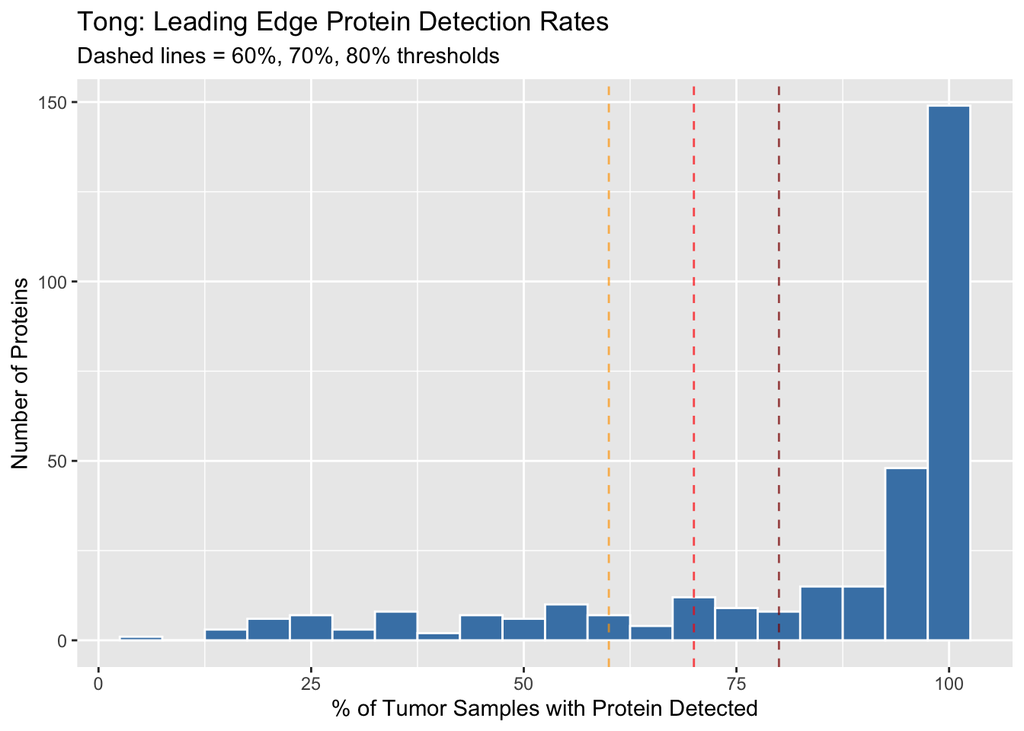

```r
# Distribution histogram
tong_df <- data.frame(DetectionRate = tong_detection[!is.na(tong_detection)])
ggplot(tong_df, aes(x = DetectionRate)) +
  geom_histogram(binwidth = 5, fill = "steelblue", color = "white") +
  geom_vline(xintercept = c(60, 70, 80), linetype = "dashed",
             color = c("orange", "red", "darkred"), alpha = 0.7) +
  labs(title = "Tong: Leading Edge Protein Detection Rates",
       subtitle = "Dashed lines = 60%, 70%, 80% thresholds",
       x = "% of Tumor Samples with Protein Detected",
       y = "Number of Proteins")
```

## 3. APGI Tumor Detection Rates

```r
apgi_detection <- sapply(leading_edge, function(p) {
  if (!p %in% colnames(apgi_prot)) return(NA)
  vals <- apgi_prot[[p]]
  round(sum(!is.na(vals)) / length(vals) * 100, 1)
})

cat("Leading edge proteins in APGI tumor samples:\n")
```

```
## Leading edge proteins in APGI tumor samples:
```

```r
cat("  Not found:", sum(is.na(apgi_detection)), "/", length(leading_edge), "\n")
```

```
##   Not found: 46 / 361
```

```r
cat("  Detected in >0%:", sum(apgi_detection > 0, na.rm = TRUE), "\n")
```

```
##   Detected in >0%: 315
```

```r
cat("  Detected in >=60%:", sum(apgi_detection >= 60, na.rm = TRUE), "\n")
```

```
##   Detected in >=60%: 258
```

```r
cat("  Detected in >=70%:", sum(apgi_detection >= 70, na.rm = TRUE), "\n")
```

```
##   Detected in >=70%: 241
```

```r
cat("  Detected in >=80%:", sum(apgi_detection >= 80, na.rm = TRUE), "\n")
```

```
##   Detected in >=80%: 217
```

```r
cat("  Detected in >=90%:", sum(apgi_detection >= 90, na.rm = TRUE), "\n")
```

```
##   Detected in >=90%: 161
```

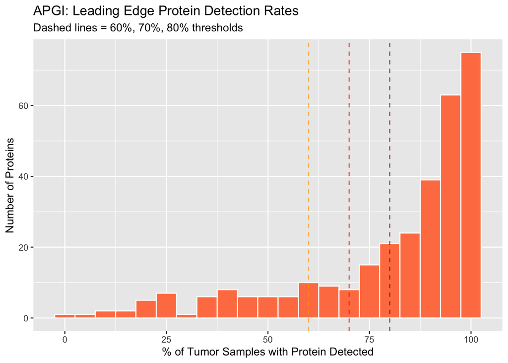

```r
# Distribution histogram
apgi_df <- data.frame(DetectionRate = apgi_detection[!is.na(apgi_detection)])
ggplot(apgi_df, aes(x = DetectionRate)) +
  geom_histogram(binwidth = 5, fill = "coral", color = "white") +
  geom_vline(xintercept = c(60, 70, 80), linetype = "dashed",
             color = c("orange", "red", "darkred"), alpha = 0.7) +
  labs(title = "APGI: Leading Edge Protein Detection Rates",
       subtitle = "Dashed lines = 60%, 70%, 80% thresholds",
       x = "% of Tumor Samples with Protein Detected",
       y = "Number of Proteins")
```

## 4. Combined Threshold Summary

```r
thresholds <- c(0, 50, 60, 70, 80, 90, 100)
tong_counts <- sapply(thresholds, function(t) sum(tong_detection >= t, na.rm = TRUE))
apgi_counts <- sapply(thresholds, function(t) sum(apgi_detection >= t, na.rm = TRUE))

summary_df <- data.frame(
  Detection_Threshold = paste0(">=", thresholds, "%"),
  Tong = tong_counts,
  APGI = apgi_counts
)
knitr::kable(summary_df,
             caption = "Number of Leading Edge Proteins Above Each Detection Threshold")
```

Number of Leading Edge Proteins Above Each Detection Threshold

| Detection_Threshold | Tong | APGI |
| --- | --- | --- |
| >=0% | 320 | 315 |
| >=50% | 281 | 273 |
| >=60% | 263 | 258 |
| >=70% | 251 | 241 |
| >=80% | 231 | 217 |
| >=90% | 205 | 161 |
| >=100% | 104 | 37 |

## 5. Signature Detection Rates in Validation Cohorts

```r
sig_proteins <- unique(c(sig$Protein, sig2$Protein))

sig_results <- data.frame(Protein = sig_proteins)

# Tong
sig_results$Tong_Pct <- sapply(sig_proteins, function(p) {
  idx <- which(symbols == p)
  if (length(idx) == 0) return(NA)
  vals <- as.numeric(tong_raw[idx, t_cols])
  round(sum(!is.na(vals)) / length(vals) * 100, 1)
})

# APGI
sig_results$APGI_Pct <- sapply(sig_proteins, function(p) {
  if (!p %in% colnames(apgi_prot)) return(NA)
  vals <- apgi_prot[[p]]
  round(sum(!is.na(vals)) / length(vals) * 100, 1)
})

knitr::kable(sig_results, caption = "Signatures: Detection Rates in Validation Cohorts",
             digits = 1)
```

Signatures: Detection Rates in Validation Cohorts

| Protein | Tong_Pct | APGI_Pct |
| --- | --- | --- |
| ADH1C | 84.1 | 65.3 |
| GPD1 | 93.8 | 84.1 |
| TNC | 100.0 | 93.8 |
| MYH11 | 100.0 | 100.0 |
| SLC2A1 | 97.3 | 88.1 |
| CD55 | 96.5 | 69.9 |
| FABP3 | 97.3 | 90.9 |
| NT5E | 99.1 | 95.5 |
| KYNU | 88.1 | 74.4 |
| KPNA2 | 88.5 | 69.3 |
| C1QC | 100.0 | 90.3 |
| GNAO1 | 96.5 | 81.8 |
| NAMPT | 100.0 | 100.0 |
| CBR1 | 100.0 | 99.4 |
| PCNA | 95.6 | 100.0 |
| ALDH9A1 | 100.0 | 100.0 |
| PYGL | 99.6 | 93.8 |
| IDH1 | 100.0 | 100.0 |
| SUCLG1 | 99.6 | 99.4 |
| GBE1 | 100.0 | 96.0 |
| SHMT2 | 100.0 | 100.0 |

## 6. Export Leading Edge Proteins with High Detection

Export the list of leading edge proteins detected in >=80% of tumor samples in both validation cohorts (Tong AND APGI). These can be prioritized for Lasso-Cox feature selection.

```r
# Proteins detected in >=80% of tumors in BOTH cohorts
tong_high <- leading_edge[which(tong_detection >= 80)]
apgi_high <- leading_edge[which(apgi_detection >= 80)]
both_high <- intersect(tong_high, apgi_high)

cat("Leading edge proteins with >=80% detection:
")
```

```
## Leading edge proteins with >=80% detection:
```

```r
cat("  Tong:", length(tong_high), "
")
```

```
##   Tong: 231
```

```r
cat("  APGI:", length(apgi_high), "
")
```

```
##   APGI: 217
```

```r
cat("  Both cohorts:", length(both_high), "
")
```

```
##   Both cohorts: 192
```

```r
# Save
write.table(both_high,
            file = here("Results", "LeadingEdge_Detected_ge80pct_BothCohorts.txt"),
            quote = FALSE, row.names = FALSE, col.names = FALSE)
cat("
Saved to Results/LeadingEdge_Detected_ge80pct_BothCohorts.txt
")
```

```
##
## Saved to Results/LeadingEdge_Detected_ge80pct_BothCohorts.txt
```